# Conference Report | Upstate NYDBER 2026

UpstateNYDBER 2026

June 11–12, 2026  
Cornell University, Ithaca, NY

| Home | Program | Report | Directions |
| --- | --- | --- | --- |

Conference Report & Consensus-Building Summary

# Upstate NYDBER 2026

Cornell University · June 11–12, 2026 — what could this region's DBER community build together that no single institution or field could build alone?

53

Pre-survey responses

9

Working group tables

21

Post-survey responses

11

Institutions represented

Upstate NYDBER 2026 brought together Discipline-Based Education Research (DBER) scholars — across Physics (PER), Biology (BER), Engineering (EER), Chemistry (CER), Geoscience (GER), and related fields — from across Upstate New York for two days at Cornell University. The conference was designed as a three-phase consensus-building process.

Before

Pre-Conference Survey

53 responses (41 completed). Hopes for the conference; ranked barriers & enablers to InterDBER collaboration.

During

Working Group Documents

9 small groups, both days. Naming specific barriers, bright spots, design principles, and draft InterDBER research questions.

After

Post-Conference Survey

21 responses (19 completed). Conference evaluation, concrete follow-up plans, and 3-month commitments.

**About this report:** Barriers and enablers below are kept close to each working group's original language on purpose — this is meant to become the input for the *next step* in the consensus process: a community-wide rating of each barrier's severity and changeability (and each enabler's potential and feasibility), which has not yet been conducted. All quotes and group notes are anonymized to theme- or group-level attribution; no individual names appear in this report.

01 · Participants

## Who Was in the Room

Nine small groups met throughout the conference, each spanning multiple institutions, DBER fields, and career stages — from graduate students to senior faculty, across R1 universities, primarily-undergraduate institutions, and community colleges.

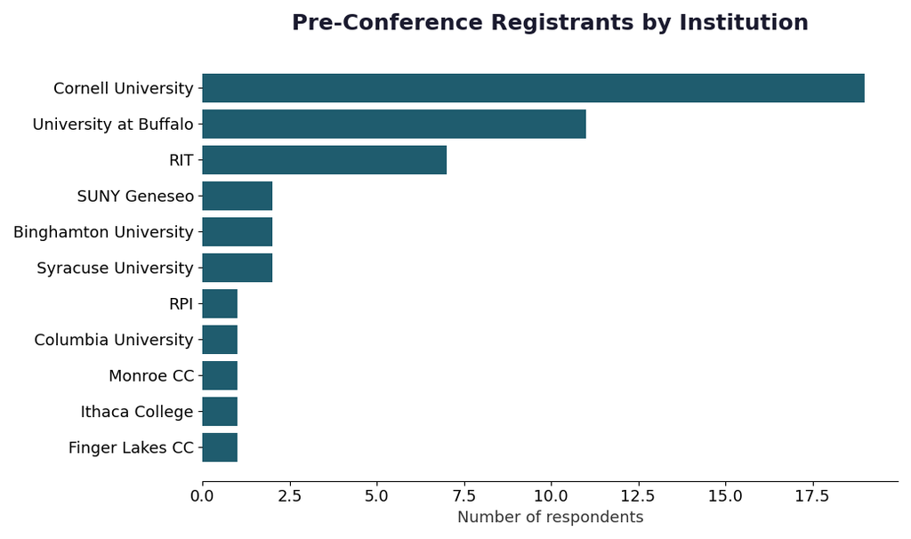

Cornell (19), University at Buffalo (11), RIT (7), Syracuse & SUNY Geneseo & Binghamton (2 each), and single registrants from Finger Lakes CC, Monroe CC, Ithaca College, RPI, and Columbia.

02 · Pre-Conference

## What People Came Hoping For

Common threads: finding collaborators with complementary skills or shared interests; learning how other DBER fields approach shared problems (assessment, AI in the classroom, retention/belonging); and bringing something concrete to the table — a dataset, methods expertise, or lived experience navigating a specific institutional barrier.

- People who have done research into ethics and identity formation; fellow EER students
- I'm open to meeting and talking with anyone in the DBER field! I do PER at the graduate level for the most part, though I am going to be adding a significant amount of focus on studying computation…
- someone who works at the intersection of math and engineering education, someone from a math program who would be interested in doing collaborative work with engineering, someone who can serve as a…
- anyone interested in programs to improve retention and student success
- People studying research groups
- Networking with EER folks interested in AI integration in higher education and who might hire me.

03 · Poster Session

## Poster Sessions

Two poster sessions ran across four tracks: **AI & Technology**, **Pedagogy & Assessment**, **Equity, Identity & Belonging**, and **Careers, Research Experiences & Curriculum/Community**. Presenters gave 30-second lightning talks before each session opened.

AI & Technology Pedagogy & Assessment Equity, Identity & Belonging Careers & Curriculum

For the full list of presenters, titles, and abstracts, visit the conference posters page.

04 · Consensus Building

## What Enables Collaboration

### Pre-conference: ranked enablers

Before the conference, participants ranked what makes cross-institutional and InterDBER collaboration work well, from most to least important.

Rank

Sample responses

1st (most important)

- Institutions being in similar time zones
- Delegation of tasks without micromanaging
- Finding stakeholders/collaborators who are interested in the same research
- a champion/leader

2nd

- Regular check-ins and meetings even when there is nothing to discuss (building habits of…
- Opportunities to network, usually in person
- Formal recognition of collaborators at other institutions through invited talks etc.
- engaged colleagues

3rd

- Establishing a relationship beyond the professional (friendships, non-work related casual…
- Sharing specialized skills or knowledge
- Institutional support (in tenure and promotion) for collaborative efforts
- common goals

### Working groups: bright spots

| Group | Enabler / Bright Spot |
| --- | --- |
| 1 | Open communication and lots of feedback between collaborators |
| 1 | Collaborations built on people who already know each other (e.g., met at a conference) |
| 1 | Mutual benefit / fair workload distribution |
| 1 | A person or people delegated to convene and organize the group |
| 1 | Clear, fair, transparent ownership across the team |
| 1 | Capitalizing on existing momentum |
| 2 | Broad planning and integration so everyone sees the big picture |
| 2 | Dedicated logistics/operations management for the collaboration |
| 3 | A welcoming, low-competition culture with strong internal collaboration (e.g., RIT CASTLE) |
| 3 | Shared desire to see the collective group succeed; shared office space |
| 3 | Regular recurring meetings (e.g., twice weekly) |
| 3 | Support structures for junior faculty |
| 4 | Unfunded traditions that build community (e.g., rotating writing retreats) |
| 4 | Scheduled recurring meetings with a set agenda |
| 4 | In-person interaction to build trust and emotional connection |
| 4 | Explicit conversations about roles, responsibilities, and authorship norms |
| 5 | Small grants to get collaborations started |
| 5 | Institutional norms/values that encourage and reward this work |
| 5 | Informal collaborations emerging from formal spaces (e.g., grad students via CASTLE) |
| 5 | Identifying complementary skills/interests early |
| 5 | Dedicated logistical leadership to keep the group moving |
| 6 | Shared communication space |
| 6 | Shared vision and goals (e.g., around state advocacy) |
| 6 | Clear leadership team plus project work teams |
| 6 | Delegation with trust and respect |
| 6 | Explicit norm-setting and shared language/expectations |
| 7 | Regular check-ins with collaborators and a clear agenda |
| 7 | Designated leaders for sub-projects with candid authorship conversations |
| 7 | Making space for individual goals by career stage |
| 7 | Explicit conversations about goals and expectations up front |
| 9 | Eager, responsive collaborators |
| 9 | Shared values across fields even without a shared disciplinary background |
| 9 | Structures that create frequent, low-stakes cross-disciplinary contact (e.g., RIT CASTLE, CDER) |
| 9 | A convener/organization that brings DBER folks together regularly |

Scroll to see all 34 entries ↑

**Cross-cutting themes:** clear/explicit communication and norm-setting; a designated convener or logistics lead; shared vision and mutual benefit; capitalizing on existing structures (centers like RIT's CASTLE, Cornell's CDER) that already create low-stakes, frequent cross-disciplinary contact; and in-person relationship-building as a precondition for trust.

05 · Consensus Building

## What Blocks Collaboration

### Pre-conference: ranked barriers

Rank

Sample responses (InterDBER-field barriers)

1st (hardest)

- Establishing networks/lack of awareness of other DBER research, especially if someone's student and post-doc…
- DBER labs or programs are often siloed (or even the only ones at their institution)
- Lack of common research interests
- field specific language

2nd

- Differences in research trends, as the topic of interest may vary across different DBER fields
- History of separation to overcome
- Lack of institutional support for initiatives of cross-collaboration
- different state of the art

3rd (easiest)

- Discipline-blind methods designs are difficult to conceive
- Different educational priorities within each field
- Lack of knowledge about people willing to collaborate
- Differing P&T/graduation requirements that have different incentive structures

### Working groups: named barriers

Each Working Group 2 table named specific barriers and sorted them as **local vs. systemic** and **movable vs. hard to change**. Presented close to verbatim group language — this is the starting list for the not-yet-conducted severity × changeability rating round.

| Group | Barrier | Local / Systemic | Movable / Hard to change |
| --- | --- | --- | --- |
| 1 | Communication (interpersonal, across institutions) | Local | Movable |
| 1 | Communication norms may differ across institutions | Both | Depends |
| 1 | Uneven incentives/resources across institutions and positions | Both | Some movable, most hard |
| 2 | Misalignment of theoretical/epistemological norms across fields | Both | Depends |
| 2 | Misalignment of methodological norms across fields | Both | Depends |
| 2 | Structure mismanagement and misallocation of project tasks | Both | Movable |
| 3 | Niche/siloed topics (e.g., quantum education) harder to find collaborators for | Systemic | Hard |
| 3 | Different time scales/timelines for faculty, postdocs, grad students | Both | Depends |
| 3 | Different fields talk about education/topics differently (jargon) | Both | Movable |
| 3 | Funding | Systemic | Hard |
| 4 | IRB limitations (institutional access, data types, cross-institution/country coordination) | Both | Hard |
| 4 | Data sharing agreements | Both | Hard |
| 4 | Time and motivation (does this align with what I'm already doing?) | Both | Hard, with mitigations |
| 4 | Buy-in (getting people to see the value added) | Both | Hard, with mitigations |
| 6 | Differing opinions/priorities among collaborators |  |  |
| 6 | Differing resources and bandwidth across institutions |  |  |
| 6 | IRB slows planning, collaboration loses momentum |  |  |
| 6 | Credit negotiation - who gets credit for the work |  |  |
| 6 | Collaboration feels like more work |  |  |
| 6 | Institutional email/spam filtering blocks outside communication |  |  |
| 7 | Power dynamics across institution types and career stage | Systemic | Hard |
| 7 | Institutional reward structures | Local | Movable/Hard |
| 7 | Scheduling and team engagement | Local | Movable with structure |
| 7 | Individual agenda consuming collective goals | Both | Movable |
| 7 | Federal funding landscape | Systemic | Hard, feels hopeless |
| 8 | Difference in values across collaborators | Both | Depends |
| 8 | Not communicating motivation and desired outcomes | Both | Depends |
| 8 | Lack of epistemic humility/curiosity | Both | Depends |
| 9 | No easy shared space to collaborate year-round without a new project | Local | Possibly movable |
| 9 | Different institutional schedules (weekly and semester/quarter) | Both | Hard |
| 9 | Research time squeeze for primarily-teaching faculty | Systemic | Hard, but workarounds possible |
| 9 | Jargon between disciplines | Systemic | Movable |
| 9 | Turnover within the community (people moving on) | Both | Hard, but workarounds possible |

Scroll to see all 33 entries ↑

**Note on Group 5:** this table reported that "almost all our barriers are systemic" without naming individual items in the structured table — a useful data point in itself about how that group perceived the landscape.

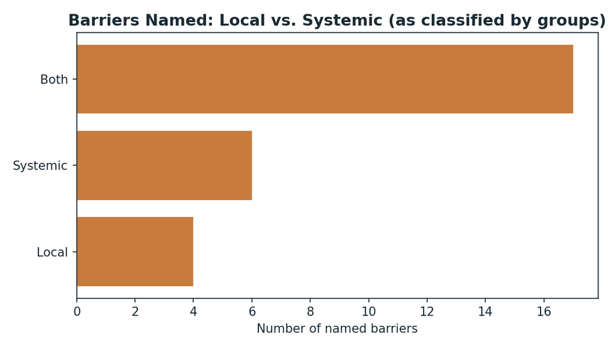

Barriers named, by local vs. systemic classification (as tagged by each group).

### Next step: the severity × changeability rating

The conference design calls for a follow-up round where all participants rate each consolidated barrier on **severity** (how much does it actually block collaboration?) and **changeability** (how realistically can this community address it?). That round has not yet run. Below is a sample of the barrier list formatted as a ready-to-send rating instrument.

| Item | Named by | Severity | Changeability |
| --- | --- | --- | --- |
| Communication (interpersonal, across institutions) | Group 1 | — | — |
| Communication norms may differ across institutions | Group 1 | — | — |
| Uneven incentives/resources across institutions and positions | Group 1 | — | — |
| Misalignment of theoretical/epistemological norms across fields | Group 2 | — | — |
| Misalignment of methodological norms across fields | Group 2 | — | — |
| Structure mismanagement and misallocation of project tasks | Group 2 | — | — |
| Niche/siloed topics (e.g., quantum education) harder to find collaborators for | Group 3 | — | — |
| Different time scales/timelines for faculty, postdocs, grad students | Group 3 | — | — |
| Different fields talk about education/topics differently (jargon) | Group 3 | — | — |
| Funding | Group 3 | — | — |
| IRB limitations (institutional access, data types, cross-institution/country coordination) | Group 4 | — | — |
| Data sharing agreements | Group 4 | — | — |

Full version in `data/wg2_barriers.csv`.

06 · Synthesis

## Design Principles for Going Forward

Each Working Group 2 table proposed 1–4 design principles for InterDBER collaboration, paired with what each would look like in practice.

| Group | Principle | In Practice |
| --- | --- | --- |
| 1 | Common vision for goals and process | Ground rules, a charter, frequent check-ins and revisions |
| 1 | No disciplinary hierarchies | Self-awareness of hierarchical/disciplinary bias; invite multiple disciplines to the table |
| 2 | Living documentation for onboarding | No single static source of truth; frequently reviewed decision log with rationale |
| 2 | Structure for projects | Assign roles/delegate early; everyone accounted for and held accountable |
| 2 | Reflexivity | Constant reflection on roles, delegation, and direction |
| 3 | Research into practice | Sharing interventions, especially with early-career/grad students |
| 3 | Sustaining involvement | At least one in-person touchpoint per year (e.g., one day in Rochester, more central) |
| 3 | Best matches | Matchmaking people working on similar ideas across fields |
| 3 | Inviting folks to give talks |  |
| 4 | Career inclusive (all ranks) | Space and time to revisit what deliverables support each person's career stage |
| 4 | Accessibility-friendly / mutual aid | Hybrid/virtual options, attendance grants for under-resourced institutions |
| 4 | Methodologically pluralistic | Include work outside STEM (psych, higher ed) |
| 4 | Non-siloed, boundaried research communities | Space for people to give and receive support across the 'not engineers, not education people' tension |
| 4 | Curiosity-enabling environments | Space to share half-baked ideas before they're polished |
| 4 | Intentional mentorship | Support for mentoring across career paths, especially into new/unsupported spaces |
| 5 | Attitude-oriented | Advocate for the legitimacy and value of social-science/ed-research approaches |
| 5 | Diversity in motivation and aspiration | Programs that support non-traditional paths, flexible electives |
| 5 | Early-career support focused | Intentional mentoring by experts to broaden novices' networks |
| 6 | Shared goals/expectations via a leadership team | One rep per institution meets each semester; point person for project requests; shared Slack |
| 6 | Shared resources, physical and instrumental | Shared classrooms, meeting spaces, recording equipment, AI APIs, data repositories, training materials |
| 7 | Individual strengths benefiting the team | Match hosting/roles to where funding and resources already exist (e.g., Cornell's large DBER network) |
| 7 | Formal documentation of team norms | Co-authorship expectations, sharing work in progress, built-in revise/reflect cadence |
| 7 | Ways to share ideas and find collaborators | A 'people-library' of research areas and collaboration philosophies |
| 7 | Strategies to integrate differing perspectives | Bring people together to share cases and strategies for change |
| 8 | Collaborative inquiry | Find your people, co-construct research questions and grants together |
| 8 | Equitable and holistic valuing of persons | Respect differential time/energy; gratitude and appreciation built in |
| 8 | Respecting epistemological diversity | Curiosity over dismissiveness across disciplinary perspectives |
| 8 | Clear expectations | Build consensus via collaboration agreements; iterate as needed |
| 9 | Multi-institutional equity of engagement | 'Horizontal hierarchy'; term-limited leadership roles; public governing documents |
| 9 | Regionally invested | Shared interest in regional workforce development, not just research |
| 9 | DEI-minded | Advocacy for policy change; public education about what DBER is |
| 9 | Member-driven priorities | Survey the community on scope (K-12/undergrad/grad, boundary disciplines) |
| 9 | Institutionally agnostic | No single-institution ownership of the website/infrastructure |
| 9 | Collaboration-minded | Shared repository of collaboration-agreement templates |

Scroll to see all 34 entries ↑

### From the Closing Visioning Session

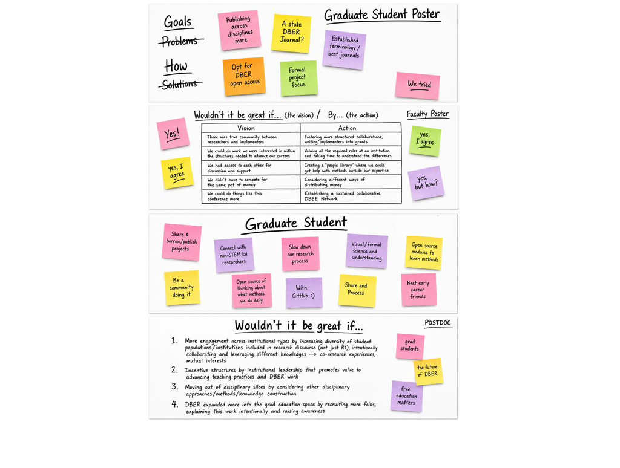

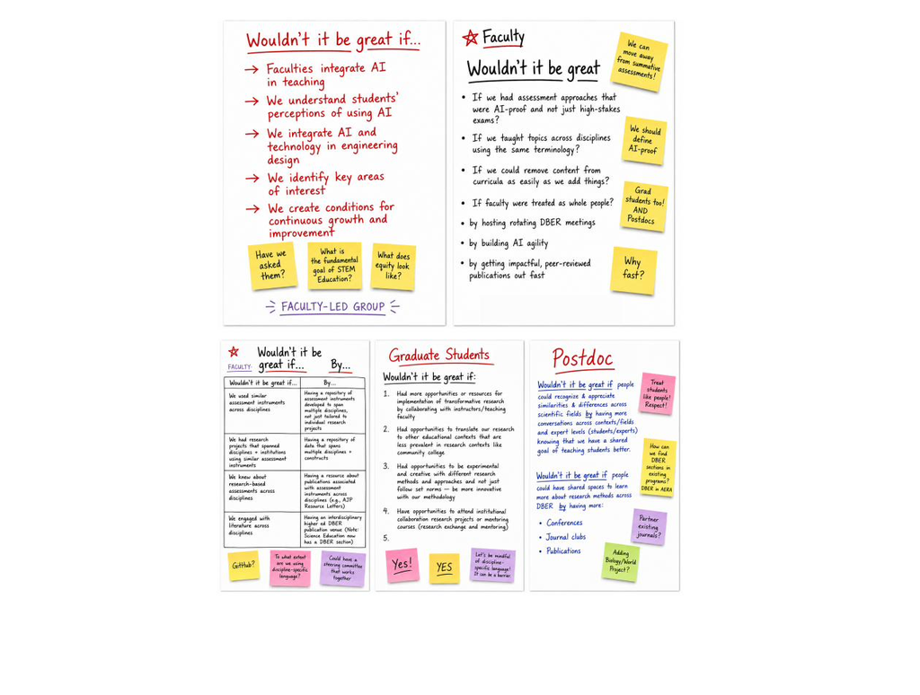

Sticky notes from the faculty, graduate student, and postdoc visioning groups.

07 · Synthesis

## Draft InterDBER Research Questions

Working Group 1 asked each table to draft 1–3 research topics that genuinely require more than one DBER field to answer well.

| Group | Draft Research Topic | Why It's InterDBER |
| --- | --- | --- |
| 1 | Universal conceptual frameworks across disciplines | Cross-field frameworks could unify how DBER fields describe learning |
| 1 | Attrition, retention, and sense of belonging | A shared concern across every DBER field |
| 1 | Technology adoption (AI, VR, and beyond) | New technologies cut across all STEM classrooms, not one discipline |
| 1 | Workforce competencies addressable across disciplines | Employers hire across disciplinary lines |
| 2 | Cross-field norms for AI use in teaching and research | Comp and bio, for example, need to reconcile norms once they collaborate |
| 2 | Institutional change / incentive structures across disciplines | Incentive structures (tenure, credit) span every DBER field |
| 3 | GenAI's impact on K-12 students before they reach STEM higher ed | Affects communication, critical thinking, and technical skills relevant to all DBER fields |
| 3 | Workforce preparation needs for STEM students | Many jobs/industries are interdisciplinary in nature |
| 4 | How instruction of foundational/service courses (e.g., stats) differs by discipline of instructor | Same content taught differently by a statistician vs. an engineer shapes student experience across fields |
| 4 | How different disciplines approach and teach 'failure' | Cross-cutting question about pedagogy and student experience |
| 4 | Shared expectations in student research training across disciplines | Design, lab, and studio training differ by field but serve overlapping goals |
| 5 | Leveraging new technology in education spaces (assessment, learning objectives) | Same technology-adoption challenge cuts across DBER fields |
| 5 | Assessing different types of learning skills across disciplinary contexts | No single field owns the assessment problem |
| 6 | Career pathways among STEM students across disciplines | STEM students often end up in careers outside their training field |
| 7 | What it means to 'know' a topic across different disciplines (e.g., intro physics vs. chem vs. calc) | Shared introductory courses serve overlapping student populations |
| 7 | How context influences [x, y, z] across institution types | Requires comparing across different types of institutions |
| 7 | How DBER as a field has changed over time across disciplines | Comparative/historical question spanning fields |
| 8 | Non-universality of math across disciplines (physics/engineering vs. math) | Different fields require different epistemological framings of the same content |
| 8 | Didactic transposition - how scientific knowledge changes when taught | Cross-field question about how knowledge is transformed for instruction and assessment |
| 9 | Overlap of coursework/skills across disciplines (e.g., engineering-physics-math) | Students take classes across DBER fields; methods should translate |
| 9 | Differing theoretical frameworks across fields | Cross-reading other fields' frameworks strengthens rigor and validity |
| 9 | Cross-cutting, non-content-specific challenges (AI, professional skills, gen-ed) | A collective front is needed since these don't belong to one discipline |

Scroll to see all 22 entries ↑

**Recurring topic clusters:** generative AI's impact on students and pedagogy (named by more tables than any other topic); cross-field workforce/career pathways; how disciplines differ in teaching foundational/shared content; and assessment across disciplinary contexts.

08 · Evaluation

## Conference Feedback

### Overall experience

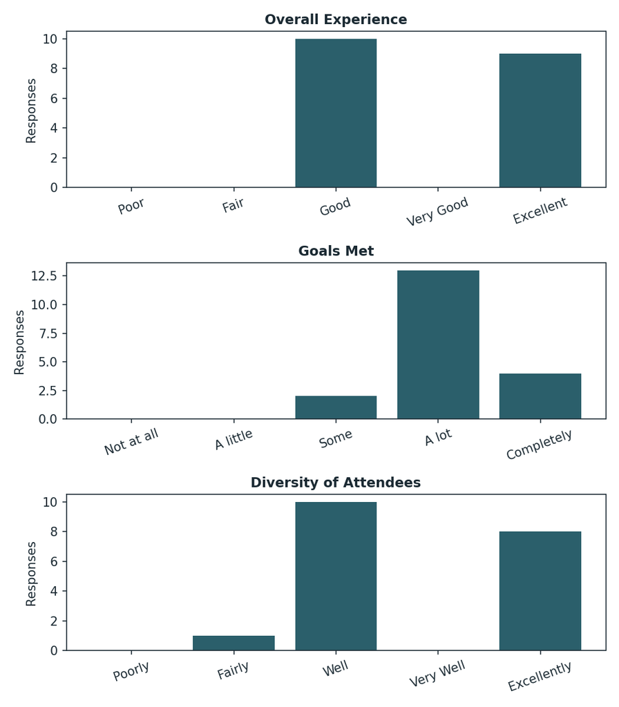

### Component ratings

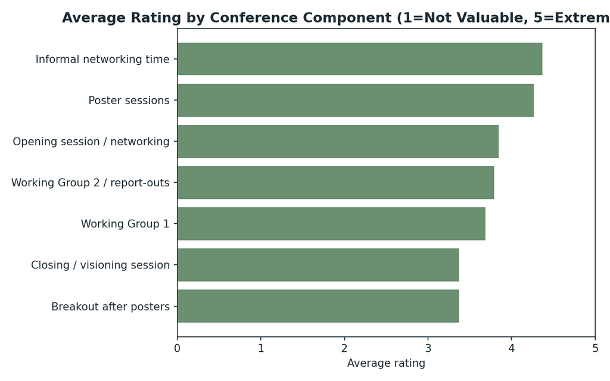

### What people said was most valuable

- Becoming aware of upstate NY institutions with DBER groups and some of the ways in which these groups are internally organized/supported (CASTLE and CDER) and making some initial connections with people in these groups.
- Networking. It was good to connect with people who are working in DBER across fields and see where we have shared interests and concerns.
- Getting feedback on work; Connecting with other DBER faculty at RIT
- I liked the poster sessions the most, and I felt that gave me the best opportunity to learn about others' research.
- Collecting together people who may otherwise not be able to attend a research conference in one place, and connecting them with folks whose primary role is research.
- meeting people from across the region and across fields
- Informal chatting time
- Making friends and sharing research in the poster session.

### What could have improved the experience

- The underlying goal seemed to be about trying to establish collaborations between DBER groups or between disciplines. But—for those of us outside of the already-established groups—I don't think we're yet in a position…
- I think having more time to talk about ongoing projects in a more structured way–birds of a feather discussions, or project ideation for collaborations would have been nice.
- I would have been interested in some talks/panel sessions. The content grouping of the posters meant that people could not see each other's work as well, but if there we 10 minute talks, we could each hear more from…
- While I found the working groups valuable, I would have preferred more opportunities to hear more deeply about other DBER research (e.g., in poster sessions or, perhaps more preferably in talks). Perhaps this sounds…
- I would have enjoyed a wider variety of activities---it felt like there was a lot of effort put on participants to make the conference valuable by continuing to have thoughtful conversation throughout the day. Maybe…
- not staying with the same group as much for working sessions
- More space and breaks for the introverts <3
- Maybe spacing the first day out a bit more. Also having some opportunities to go on walks/hikes with the visitors and doing informal active activities with them.

### Likely follow-through

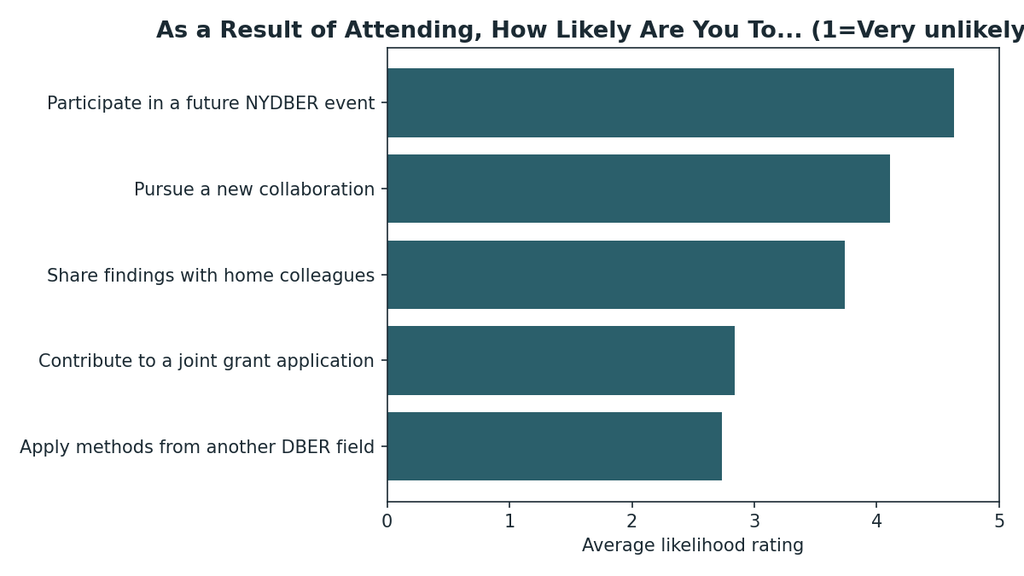

09 · Looking Ahead

## Where This Goes Next

### Sustainability mechanisms people said they'd actually use

Combining post-survey selections (Q24) with closing-session table enthusiasm ratings (1–5 scale):

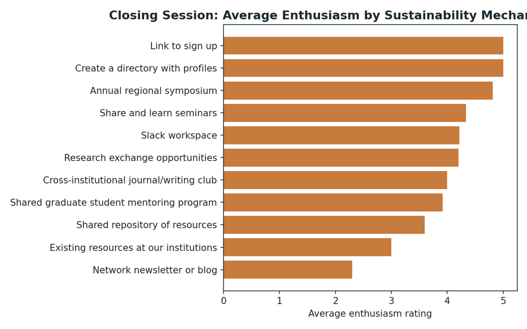

Closing-session average enthusiasm by mechanism (1–5 scale).

| Mechanism | Times selected (post-survey) |
| --- | --- |
| Annual regional symposium | 15 |
| Slack workspace for updates and communication | 13 |
| Virtual seminar series (e.g., works-in-progress presentations) | 12 |
| Shared graduate student training or mentoring program | 12 |
| Cross-institutional reading or writing group (monthly, virtual) | 9 |
| Shared repository of instruments, protocols, and resources | 8 |
| Listserv / email list | 7 |
| Job and opportunity sharing (postings, dissertation defenses, etc.) | 6 |
| Writing retreats (in-person or virtual) | 6 |
| Network newsletter or blog for sharing works-in-progress | 4 |

**Highest and most consistent enthusiasm:** annual regional symposium, "share and learn" seminars, and research exchange opportunities. **Most divided:** a network newsletter/blog and a shared digital repository — both drew high interest from some tables and low interest from others, usually tied to who would maintain them.

### Three-month commitments

- I don't have anything specific in mind. I already have several other research projects going (and 20 credits to teach each year). I'd love to collaborate with others in the group, but don't have the…
- Happy to contribute to a virtual seminar.
- Connecting with other folks locally.
- I would love to work more with folks at neighboring institutions. I've already reached out to a couple to continue the conversation.
- I don't think I will? I am excited about my collaboration, but I don't think that meaningfully contributes to this community. I would be willing to participate in a slack workspace if it was set up…
- helping start an interDBER journal club
- As a member of CDER leadership, I'm going to try to make solid steps towards establishing the open monthly lit clubs we talked about in collaboration with CASTLE
- I will follow up with two people I've just met to see how they are doing!